# Report for Job [KEY:lncRNA_lncRNA_Cor__Spearman__No]

WGIA

2024-08-13 20:11:10

**You can bookmark this page to access the results later, or [download the report](http://gpu.zjwm.cc:88/wgia/public/job/lncRNA_lncRNA_Cor__Spearman__No/report.html) locally.**

*Results will be stored for 30 days.*

> WGIA is an open-access web application designed for genome-wide interaction analysis. Leveraging GPU parallel technologies, it significantly enhances computational efficiency. You can upload the SNP, DNA methylation, gene expression, or other biological data, and WGIA generates a comprehensive report within a short timeframe.

# 1. Datasets information

## 1.1 marker information

**There are total 100 long non-coding RNA (lncRNA) used for interaction analysis.**

- In order to provide the fullest results as possible, WGIA provided interaction for all the lncRNA uploaded, with out quality control for the data.
- Note: If needed, some basic information about lncRNA can be used to perform quality control before uploaded the datasets, such as the missing rate.

## 1.2 sample information

**There are total of 50 samples used for interaction calculation.** **Note: There are no other sample information be used.**

# 2. Interaction analysis results

## 2.1 Correlation distribution

**The WGIA performed a total of 4,950 calculations between 100 lncRNA for this job, encompassing correlation coefficients (Spearman) among all possible lncRNA-lncRNA pairs. The results are displayed below.**

> **lncRNA CoExpression:** lncRNA CoExpression analysis evaluates the correlation of lncRNA expression levels with other genes to explore their potential regulatory roles.  
> **Spearman:** Spearman correlation assesses the rank-order relationship between two variables, making it suitable for non-linear associations and ordinal data.

**The plot below displays the distribution of the Correlation of all the 4,950 lncRNA-lncRNA pairs (markers) in the dataset.**

- These results can be downloaded here Cor_distribution.txt.

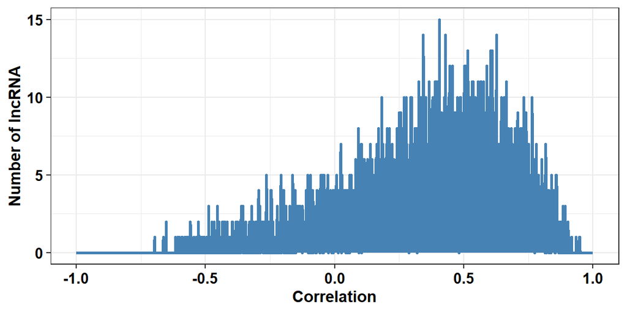

- A more rough distribution of intervals is as follows:

|  | lower_interval | upper_interval | frequency |
| --- | --- | --- | --- |
| 1 | -0.8 | -0.6 | 9 |
| 2 | -0.6 | -0.3999999999999999 | 75 |
| 3 | -0.3999999999999999 | -0.2 | 190 |
| 4 | -0.2 | 0 | 371 |
| 5 | 0 | 0.2000000000000002 | 676 |
| 6 | 0.2000000000000002 | 0.4000000000000001 | 1049 |
| 7 | 0.4000000000000001 | 0.6000000000000001 | 1355 |
| 8 | 0.6000000000000001 | 0.8 | 1009 |
| 9 | 0.8 | 1 | 192 |

## 2.2 Correlation distribution metrics

**Some basic information about the distribution is provided in the table below, including mean value, variance, standard deviation, skewness, kurtosis, median_value, lower quartile, upper quartile, interquartile range.**

- **Mean value**: The average value of the data set.
- **Variance**: A measure of how much the data points differ from the mean.
- **Standard deviation**: The square root of the variance, indicating the spread of the data.
- **Skewness**: A measure of the asymmetry of the data distribution.
- **Kurtosis**: A measure of the “tailedness” of the data distribution.
- **Median value**: The middle value that separates the higher half from the lower half of the data set.
- **Lower quartile (Q1)**: The median of the lower half of the data set (25th percentile).
- **Upper quartile (Q3)**: The median of the upper half of the data set (75th percentile).
- **Interquartile range (IQR)**: The range between the lower quartile and the upper quartile (Q3 - Q1), measuring the spread of the middle 50% of the data.
- These results can be downloaded here Cor_distribution.txt. The last 9 line of the file are the metric values of the distribution.

|  | metrics | value |
| --- | --- | --- |
| 1 | mean value | 0.365331 |
| 2 | variance | 0.093183 |
| 3 | standard deviation | 0.305259 |
| 4 | skewness | -0.020211 |
| 5 | kurtosis | 0.026825 |
| 6 | lower quartile | 0.176833 |
| 7 | median_value | 0.414000 |
| 8 | upper quartile | 0.596083 |
| 9 | interquartile range | 0.419250 |

- These results can be downloaded here Cor.txt.

  | Marker1 | Marker2 | Correlation | Lower | Upper | t-statistic |
  | --- | --- | --- | --- | --- | --- |
  | LINC00269 | LINC00271 | 0.766050 | 0.619875 | 0.860843 | 8.256866 |
  | LINC00269 | LINC00272 | 0.579524 | 0.359098 | 0.738713 | 4.926720 |
  | LINC00269 | LINC00273 | 0.525186 | 0.289095 | 0.701054 | 4.275734 |
  | LINC00269 | LINC00276 | -0.081873 | -0.352199 | 0.201062 | -0.569142 |
  | LINC00269 | LINC00278 | 0.260751 | -0.018980 | 0.502622 | 1.871267 |
  | LINC00269 | LINC00280 | 0.164274 | -0.119545 | 0.423272 | 1.153796 |

- If you need the full results, Please perform the interaction analysis with our local software WGIA.exe